# 16_A_SES_ModelFitting

```r
library(fpp3)
```

# What this workshop teaches

This workshop teaches you how to **fit a simple exponential smoothing (SES) model**: estimate the smoothing weight $\alpha$ and the initial level $\ell_0$ from observed data. In Session 15 on SES equations, we updated the level using given values of these quantities, but here we learn how to choose them.

A **candidate fit** is a trial pair of values for $\alpha$ and $\ell_0$ that we might choose as our parameter estimates. Each pair generates its own predictions for the same observations, so we can compare candidate fits by the sum of squared prediction errors (SSE): the smaller the score, the closer the fit to the training data. Since we cannot score every possible pair by hand, a numerical optimizer searches for a lower SSE.

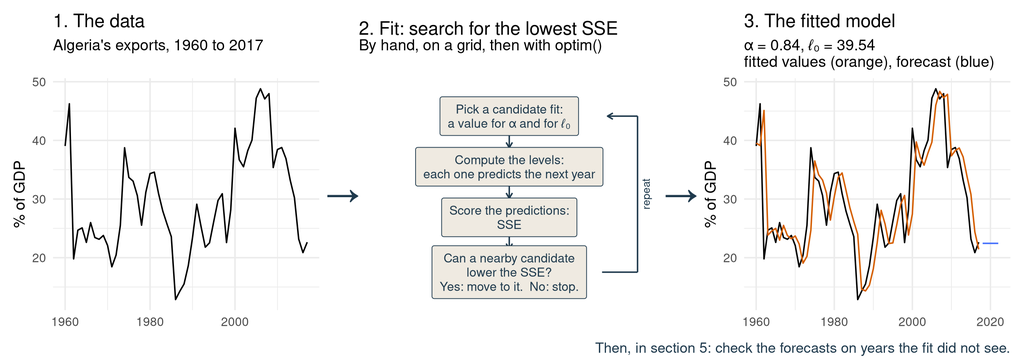

A **candidate** is any given pair of values for $\alpha$ and $\ell_0$. Scoring a candidate means computing its predictions and their squared errors.

The required workshop is sections 1 to 5. Score candidate fits by hand, read and check the supplied functions, automate the hand grid, then use a numerical optimizer to search both parameters. Interpret its outputs, compare with the library and check forecasts on held-out observations. Explain what the fitted parameters, objective and convergence report tell you. R argument syntax and the optimizer’s algorithm are not examination topics.

The required homework is 16_B. The appendix contains optional interface reference and another fitting practice: neither is required for homework, the group assignment or exams.

## Before the code: score two candidate fits

Take a tiny made-up series with three consecutive observations, $y_1=8$, $y_2=12$ and $y_3=10$. These numbers are the data values, not positions in a longer series. Each prediction uses the preceding level. After scoring that prediction, update the level using the observation. Recalculate the whole sequence whenever either parameter changes.

**Timing check.** Take $\alpha=0.6$ and $\ell_0=9$. What predicts $y_1$? After seeing $y_1=8$, what predicts $y_2$? Commit to both answers before opening the comparison.

**TipWorked comparison: open after the timing check**

The prediction for $y_1$ uses the initial level, $\hat y_{1|0}=\ell_0=9$. After observing $y_1=8$, we update the level using the SES level equation:

$$\ell_1=\alpha y_1+(1-\alpha)\ell_0=0.6\times8+(1-0.6)\times9=8.4.$$

The prediction for $y_2$ is therefore $\hat y_{2|1}=\ell_1=8.4$. Each prediction is the level before that observation arrives.

Now let’s add another candidate and compute the SSE for both cases, using the squared prediction errors as in Session 15 on SES equations. The pair from the timing check is labeled B below; the additional pair is A.

| Candidate fit | $\alpha$ | $\ell_0$ | Predictions $\ell_0, \ell_1, \ell_2$ of $y_1, y_2, y_3$ | Residuals | SSE |
| --- | --- | --- | --- | --- | --- |
| A | 0.2 | 8 | 8, 8, 8.8 | 0, 4, 1.2 | 17.44 |
| B | 0.6 | 9 | 9, 8.4, 10.56 | -1, 3.6, -0.56 | 14.2736 |

Candidate fit B has the smaller training score among these two trials. This comparison neither establishes a global minimum (i.e., the best overall candidate) nor shows which candidate fit forecasts later observations better.

### Check: fit on a small grid

Keep the same series, $y_1=8$, $y_2=12$, $y_3=10$, and fix the initial level at $8$. Calculate the predictions and SSE for $\alpha=0.2, 0.4, 0.6, 0.8$. Which candidate fits share the smallest score? After comparing answers in class, try $\alpha=0.5$: does the best candidate fit on the original grid exhaust the possible choices?

**TipWorked answer: open after you have tried**

Because $\ell_0=y_1=8$, the first residual is $0$ and $\ell_1=\alpha\times8+(1-\alpha)\times8=8$ for every $\alpha$. So $y_2=12$ is always predicted by $8$, with residual $4$. Only the third prediction depends on $\alpha$:

$$\ell_2=\alpha\times12+(1-\alpha)\times8=8+4\alpha,
\qquad
\operatorname{SSE}=0^2+4^2+(10-\ell_2)^2=16+(2-4\alpha)^2.$$

| $\alpha$ | Predictions $\ell_0, \ell_1, \ell_2$ | Residuals | SSE |
| --- | --- | --- | --- |
| 0.2 | 8, 8, 8.8 | 0, 4, 1.2 | 17.44 |
| 0.4 | 8, 8, 9.6 | 0, 4, 0.4 | 16.16 |
| 0.6 | 8, 8, 10.4 | 0, 4, -0.4 | 16.16 |
| 0.8 | 8, 8, 11.2 | 0, 4, -1.2 | 17.44 |
| 0.5 | 8, 8, 10 | 0, 4, 0 | 16 |

On the grid, $\alpha=0.4$ and $\alpha=0.6$ share the smallest score, 16.16. The score cannot choose between them. Here, trying a value between the tied candidates improves the score: $\alpha=0.5$ makes $2-4\alpha=0$ and scores 16, the lowest possible with $\ell_0$ fixed at 8. A grid only compares the candidates on it; a finer grid or a numerical search can find better values between its points.

## 1. Read and check the function that computes the levels

`ses_levels(y, alpha, l_0)` uses the **recursive weighted-average form**, the first of the four equivalent forms in Session 15 on SES equations. It combines the new observation with the previous level, giving them weights $\alpha$ and $1-\alpha$. The function applies this update once per observation and returns the initial level and every update. The equations are:

$$\hat y_{t|t-1}=\ell_{t-1},\qquad
e_t=y_t-\ell_{t-1},\qquad
\ell_t=\alpha y_t+(1-\alpha)\ell_{t-1}.$$

The loop below uses `t` for observation time. R position `t` stores $\ell_{t-1}$, and position `t + 1` stores $\ell_t$. With $T$ observations, the first $T$ entries are their predictions; the final entry is the level after the last observation and supplies the flat future forecast.

| Observation time | Level used to predict it | Where the supplied code stores that level |
| --- | --- | --- |
| 1 | $\ell_0$ | `levels[1]` |
| 2 | $\ell_1$ | `levels[2]` |
| $T$ | $\ell_{T-1}$ | `levels[T]` |
| Future $T+1$ | $\ell_T$ | `levels[T + 1]` |

Read the function alongside the prediction and update equations, then check it against the reference file below.

```r
ses_levels <- function(y, alpha, l_0) {
  levels <- numeric(length(y) + 1)
  levels[1] <- l_0
  for (t in seq_along(y)) {
    levels[t + 1] <- alpha * y[t] + (1 - alpha) * levels[t]
  }
  levels
}
```

`numeric(length(y) + 1)` reserves one position for the initial level and one for each update. With $T$ observations, we therefore store $T+1$ levels, $\ell_0,\ell_1,\ldots,\ell_T$. For example, three observations produce four stored levels: the first three predict $y_1,y_2,y_3$, while the fourth is the updated level after observing $y_3$ and supplies the forecast for $y_4$ and later observations.

### Check the levels against a reference file

Use Algeria’s annual exports, measured as a percentage of GDP: 58 observations, 1960 to 2017. In Session 15 on SES equations we fitted SES to this series with `fable` and obtained $\alpha\approx0.84$ and $\ell_0\approx39.54$. The reference file `yhat_SES_test` stores the 59 levels $\ell_0, \ell_1, \dots, \ell_{58}$ of that model, computed with those two estimates to seven decimals. If `ses_levels()` is correct, it reproduces the same 59 levels from the same $\alpha$ and $\ell_0$. These fixed values only test the function. The numerical search in section 4 is a different step: `optim()` starts from $\alpha=0.1$ and $\ell_0=y_1$ and estimates both parameters itself.

```r
algerian_exports <- global_economy |>
  filter(Country == "Algeria") |>
  select(Year, Exports)
```

Before checking the function, inspect the first six entries of its output. They are $\ell_0,\ell_1,\ldots,\ell_5$: the first is the initial level, and each subsequent entry is the level after incorporating one more observation.

```r
y <- algerian_exports$Exports
levels_function <- ses_levels(y, alpha = 0.8399875, l_0 = 39.5389994)
head(levels_function)
```

```
[1] 39.53900 39.12251 45.10494 23.84396 24.55016 24.99863
```

Now compare all 59 returned levels with the reference vector:

```r
levels_test <- dget("../../data/yhat_SES_test")
all.equal(levels_function, levels_test)
```

```
[1] TRUE
```

The check should return `TRUE`. If it fails, check that the first prediction is the initial level and that each prediction precedes its observation. The path `../../data/` is relative to this session’s folder. If R cannot find the file, set the working directory there first: in RStudio, open `session16_code.R` and choose Session > Set Working Directory > To Source File Location. The appendix explains the spreadsheet labels and interface details if you need them.

## 2. Read and check the supplied squared-error score

`SSE_func(y, yhat)` compares equally long vectors of observations and one-step predictions. It subtracts predictions from observations and adds the squared residuals:

$$\operatorname{SSE}(\alpha,\ell_0)=\sum_{t=1}^{T}(y_t-\ell_{t-1})^2.$$

```r
SSE_func <- function(y, yhat) {
  residuals <- y - yhat
  SSE <- sum(residuals^2)
  SSE
}
```

To obtain a reference score, refit the same `fable` model used in Session 15 on SES equations. `augment()` supplies its residuals, which we square and add:

```r
reference_fit <- algerian_exports |>
  model(ETS(Exports ~ error("A") + trend("N") + season("N")))
reference_residuals <- augment(reference_fit)$.resid
reference_SSE <- sum(reference_residuals^2)
reference_SSE
```

```
[1] 1995.285
```

This gives an SSE of 1995.285. With the same $\alpha$ and $\ell_0$, our two functions should reproduce that score to three decimal places. Only the first 58 levels, $\ell_0$ to $\ell_{57}$, predict observations. The last level, $\ell_{58}$, is the forecast for 2018 onward, so it is left out of the score.

In `fixed_levels[seq_along(y)]`, `seq_along(y)` produces the positions `1, 2, ..., 58`, and the square brackets select those entries from `fixed_levels`. Because the first stored entry is $\ell_0$, this selects $\ell_0$ through $\ell_{57}$, giving one prediction for each observation in `y` and leaving out the final level $\ell_{58}$.

```r
y <- algerian_exports$Exports
fixed_levels <- ses_levels(y, alpha = 0.8399875, l_0 = 39.5389994)
SSE_test <- SSE_func(y, fixed_levels[seq_along(y)])
SSE_test
```

```
[1] 1995.285
```

```r
all.equal(round(reference_SSE, 3), round(SSE_test, 3))
```

```
[1] TRUE
```

## 3. Pro tip: return a candidate fit’s SSE in a single step

We have already calculated a candidate’s SSE using `ses_levels()` and `SSE_func()`. For convenience, `my_ses_sse()` puts those same calls into one function, so we can take one candidate fit and return its SSE in a single step. It computes the levels, keeps the 58 predictions and scores them, just as we did in section 2.

The candidate is passed as one vector, `par`: `par[1]` is $\alpha$ and `par[2]` is $\ell_0$. The data stay in the separate argument `y`. The grid and the numerical search below use this shortcut to repeat the calculation for many candidates.

```r
my_ses_sse <- function(par, y) {
  levels <- ses_levels(y, alpha = par[1], l_0 = par[2])
  predictions <- levels[seq_along(y)]
  SSE_func(y, predictions)
}
```

### Check it against the score from section 2

Using the same $\alpha$ and $\ell_0$, first print the single SSE returned by `my_ses_sse()`, then check that it matches the two-step calculation in section 2, 1995.285.

```r
my_ses_sse(c(0.8399875, 39.5389994), y)
```

```
[1] 1995.285
```

```r
all.equal(SSE_test, my_ses_sse(c(0.8399875, 39.5389994), y))
```

```
[1] TRUE
```

## 4. Run the search and interpret the evidence

### Automate the hand grid with finer spacing

The hand example compared a preset list of alpha values, which is called a **grid search**. Now automate the same calculation for the Algeria data set with finer spacing. For each candidate alpha, recompute the levels over the full series and calculate SSE.

To keep this first search to one parameter, we hold the initial level at the first observation, $\ell_0=y_1$. This is a simplifying choice for this exercise, rather than an estimate of the initial level. In [fpp3 section 8.1](https://otexts.com/fpp3/exponential-smoothing.html#optimisation), both $\alpha$ and $\ell_0$ are estimated from the data; our numerical search below will allow both to vary too. The initial level affects the predictions and SSE, so changing it can also change which alpha the grid selects.

The code below uses `sapply()` to repeat the calculation:

- `alpha_grid` lists the 99 alpha values from 0.01 to 0.99.
- `function(alpha) { ... }` defines a small function that takes one of those values and returns its SSE. Within it, `c(alpha, y[1])` supplies the candidate pair: the current alpha and the fixed initial level.
- `sapply()` calls that function once for each value in `alpha_grid` and collects the 99 scores in `grid_SSE`, in the same order. It therefore repeats the scoring for us rather than requiring 99 separate calls.

For example, the first call is `my_ses_sse(c(0.01, y[1]), y)`, the second uses 0.02, and so on. Each call recalculates the levels for all 58 observations and returns one SSE. We then put the alpha values and their scores side by side in `grid_results`.

```r
alpha_grid <- seq(0.01, 0.99, by = 0.01)
grid_SSE <- sapply(alpha_grid, function(alpha) {
  my_ses_sse(c(alpha, y[1]), y)
})
grid_results <- tibble(alpha = alpha_grid, SSE = grid_SSE)
grid_best <- grid_results |> slice_min(SSE, n = 1)
grid_best
```

```
# A tibble: 1 × 2
  alpha   SSE
  <dbl> <dbl>
1  0.84 1996.
```

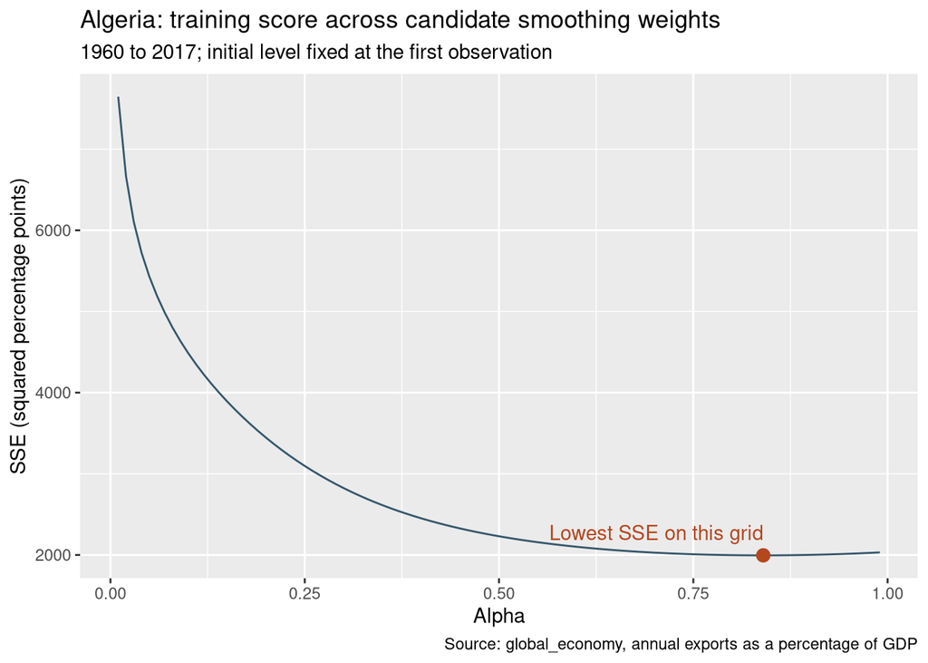

```r
grid_results |>
  ggplot(aes(x = alpha, y = SSE)) +
  geom_line(color = "#35576B") +
  geom_point(data = grid_best, color = "#B5471E", size = 3) +
  geom_text(data = grid_best, label = "Lowest SSE on this grid",
            hjust = 1, vjust = -1, color = "#B5471E") +
  labs(title = "Algeria: training score across candidate smoothing weights",
       subtitle = "1960 to 2017; initial level fixed at the first observation",
       x = "Alpha", y = "SSE (squared percentage points)",
       caption = "Source: global_economy, annual exports as a percentage of GDP")
```

Selecting the lowest score estimates $\alpha$: among these 99 candidates, 0.84 gives the smallest SSE when $\ell_0=y_1$. We have therefore chosen a smoothing weight from the data using the SSE criterion. Smaller spacing gives finer coverage, but this grid still leaves gaps between its points and keeps the initial level fixed. Next, let a numerical optimizer choose new trial values and vary both parameters.

### Use a numerical optimizer to search both parameters

A grid only scores candidates we listed in advance. To search $\alpha$ and $\ell_0$ together we would also need a range and a spacing for $\ell_0$, and the best pair could still fall between grid points. The models in later sessions have more parameters, and the list grows quickly with each one.

A **numerical optimizer** chooses new trial values as it searches, including values between the earlier grid points. It starts from one candidate fit and scores it. It then uses the scores it has seen so far to choose the next candidate in a direction where the SSE falls, and stops when further moves no longer lower the score noticeably. Picture a walker in fog looking for the bottom of a valley. They cannot see the whole landscape, as the grid curve above does, but they can feel which way the ground slopes and keep stepping downhill until it is flat. Like that walker, the search can also stop in a small dip that is not the lowest point, which is why its report needs careful reading below.

R’s general-purpose optimizer is `optim()`. It knows nothing about SES: it minimizes any function that turns a vector of parameters into one number. That is why `my_ses_sse()` takes the candidate as one vector `par` and returns one SSE. The `ETS()` function in `fable` runs the same kind of search internally when it estimates a model; here each piece is visible.

| Argument | What it is here |
| --- | --- |
| `fn = my_ses_sse` | The function to minimize (the one we made ourselves above): one candidate fit in, its SSE out |
| `par = c(0.1, y[1])` | Where the search starts: $\alpha=0.1$ and $\ell_0=y_1$. These are starting guesses, not fixed values; the search changes both |
| `y = y` | The data, passed on to `my_ses_sse()` unchanged |
| `method = "L-BFGS-B"` | Which numerical search algorithm to use; this one supports lower and upper limits on the parameters |
| `lower`, `upper` | The limits for $\alpha$ and $\ell_0$, in the same order as `par`: keep $\alpha$ between 0.0001 and 0.9999 and leave $\ell_0$ unrestricted |

The `method` argument selects the search algorithm. Here we use **L-BFGS-B**, short for *limited-memory BFGS with bounds*: it uses local slope information to choose parameter updates and can respect lower and upper limits. The final **B** refers to those **bounds**, which we supply through `lower` and `upper`. We choose this method so that the search can vary $\alpha$ within its allowed range while also estimating $\ell_0$. In the limits below, `-Inf` and `Inf` mean that we impose no lower or upper limit on the initial level. See [R’s documentation for `optim()`](https://stat.ethz.ch/R-manual/R-devel/library/stats/html/optim.html) for the algorithm details.

Understanding **L-BFGS-B** is not graded in this course.

```r
opt <- optim(par = c(0.1, y[1]),
             fn = my_ses_sse, y = y,
             method = "L-BFGS-B",
             lower = c(0.0001, -Inf), upper = c(0.9999, Inf))
```

### Interpret the search outputs

Read the result through these three outputs:

```r
opt$par
```

```
[1]  0.8397832 39.5381573
```

```r
opt$value
```

```
[1] 1995.285
```

```r
opt$convergence
```

```
[1] 0
```

`opt$value` prints as 1995.285, matching the score we calculated before using `optim()`. This agreement reflects how we set up the illustration: the earlier check used rounded parameter estimates from the `fable` fit, so it was already scoring a fitted model. Our search finds slightly different parameters and an SSE that agrees at the displayed precision; the unrounded scores differ slightly. With arbitrary candidate values, or on another data set, the score before the search need not match the optimized score. The purpose here is to reproduce a known fit while seeing how the search chooses its parameters.

| Output | Meaning | Limit of the evidence |
| --- | --- | --- |
| `par` | Estimated alpha and initial level | Their practical effect appears in predictions and forecasts. |
| `value` | Training SSE at those estimates | A smaller score on matching data establishes better training fit. |
| `convergence` | Search completion status; `0` reports successful completion, while nonzero codes flag a stopping problem or warning | It does not certify a global minimum, correct code or useful future forecasts. |

`opt$message` provides more detail about why the search stopped. In this run, it reports that further reductions in SSE became too small under the algorithm’s stopping tolerance. That explains the `0`; it does not mean that SSE itself is zero. For a nonzero code, read the message to identify the stopping problem or warning, and consult [R’s `optim()` documentation](https://stat.ethz.ch/R-manual/R-devel/library/stats/html/optim.html) if needed.

Starting guesses, bounds and stopping rules can affect the numerical result. Two implementations can therefore return slightly different estimates without either being incorrectly coded. Compare the objective, fitted values and forecasts, rather than demanding the same parameter digits.

**NoteSupporting reading: a likelihood preview for Session 19**

SSE is our chosen fitting criterion. Session 19 on ETS estimation and model selection uses likelihood. For the same additive-normal model, observations and parameter constraints, maximizing the conditional Gaussian likelihood selects the same parameter optima as minimizing SSE. This equivalence does not say that every fitting criterion is SSE, or that numerical searches must return identical parameter digits.

### Compare with the library

Now fit the same model with `fable`, exactly as in Session 15 on SES equations, and compare each result with ours using the same tools: `tidy()` for the parameters, `augment()` for the fitted values and residuals, and `forecast()` with `autoplot()` for the forecasts.

```r
fit <- algerian_exports |>
  model(ETS(Exports ~ error("A") + trend("N") + season("N")))

# Parameters: fable's estimates next to ours from optim()
tidy(fit) |>
  select(term, fable = estimate) |>
  mutate(optim = opt$par)
```

```
# A tibble: 2 × 3
  term   fable  optim
  <chr>  <dbl>  <dbl>
1 alpha  0.840  0.840
2 l[0]  39.5   39.5
```

Our fitted values are the levels $\ell_0, \dots, \ell_{57}$ computed with the estimates from `optim()`. Place them next to the `.fitted` column of `augment()`:

```r
manual_levels <- ses_levels(y, opt$par[1], opt$par[2])

fitted_compare <- augment(fit) |>
  select(Year, Exports, .fitted, .resid) |>
  mutate(manual_fitted = manual_levels[seq_along(y)])

fitted_compare |> head(3)
```

```
# A tsibble: 3 x 5 [1Y]
   Year Exports .fitted  .resid manual_fitted
  <dbl>   <dbl>   <dbl>   <dbl>         <dbl>
1  1960    39.0    39.5  -0.496          39.5
2  1961    46.2    39.1   7.12           39.1
3  1962    19.8    45.1 -25.3            45.1
```

```r
fitted_compare |> tail(3)
```

```
# A tsibble: 3 x 5 [1Y]
   Year Exports .fitted .resid manual_fitted
  <dbl>   <dbl>   <dbl>  <dbl>         <dbl>
1  2015    23.2    30.8  -7.63          30.8
2  2016    20.9    24.4  -3.53          24.4
3  2017    22.6    21.4   1.21          21.4
```

```r
# Training SSE: ours, then fable's from the augment() residuals
c(manual_SSE = opt$value,
  fable_SSE = sum(fitted_compare$.resid^2))
```

```
manual_SSE  fable_SSE
  1995.285   1995.285
```

Finally, the forecasts. SES forecasts are flat, so every future value equals the last level: our last level, $\ell_{58}$, should match each of `fable`’s five point forecasts.

```r
fc <- fit |> forecast(h = 5)
fc$.mean
```

```
[1] 22.44468 22.44468 22.44468 22.44468 22.44468
```

```r
tail(manual_levels, 1)
```

```
[1] 22.4446
```

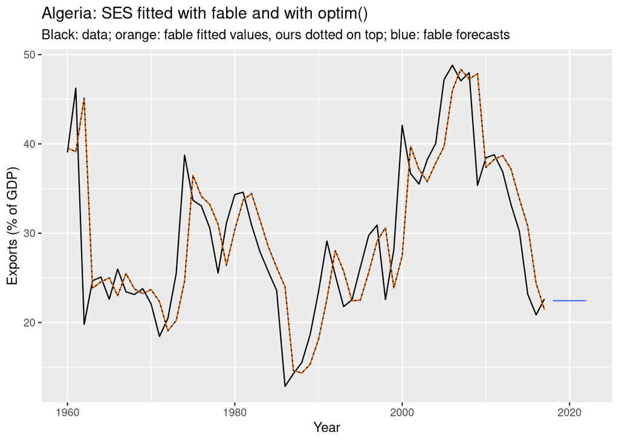

```r
fc |>
  autoplot(algerian_exports, level = NULL) +
  geom_line(aes(y = .fitted), data = augment(fit), colour = "#D55E00") +
  geom_line(aes(y = manual_fitted), data = fitted_compare,
            colour = "black", linetype = "dotted") +
  labs(title = "Algeria: SES fitted with fable and with optim()",
       subtitle = "Black: data; orange: fable fitted values, ours dotted on top; blue: fable forecasts",
       y = "Exports (% of GDP)", x = "Year")
```

The two fits agree closely, with small numerical differences: the SSEs match to three decimals, and the forecasts differ only in the fifth digit (22.44468 and 22.4446). With more digits the estimates also differ slightly ($\alpha$ is 0.8400 in `fable` and 0.8398 here) because the two searches use different methods and starting points, as discussed above.

If the fits disagree materially, check the data, model, objective and bounds, inspect the completion status, and try another starting pair. Residual diagnostics examine what structure remains. Held-out forecasts at a stated horizon provide evidence about predictive performance.

## 5. Compare forecasts on the test set

The **holdout set** here is the **test set** from our train/test split: observations kept out of fitting so we can evaluate the forecasts.

Now move the forecast origin back to the end of 2012. Training uses 1960 to 2012; the test set covers 2013 to 2017. We compare SES fitted by `fable`, our SES grid fit, and naive. All three fits forecast horizons one to five from that single origin, without updating on the test observations. Refit everything using the training data, including the alpha grid and its final level. The full-series estimates above cannot enter this comparison.

### Split the data before fitting

The training set contains 53 observations, and the test set contains five. Print the first three training rows and the complete test set so we can see their columns and years:

```r
training <- algerian_exports |> filter(Year <= 2012)
test_set <- algerian_exports |> filter(Year >= 2013, Year <= 2017)
head(training, 3)
```

```
# A tsibble: 3 x 2 [1Y]
   Year Exports
  <dbl>   <dbl>
1  1960    39.0
2  1961    46.2
3  1962    19.8
```

```r
test_set
```

```
# A tsibble: 5 x 2 [1Y]
   Year Exports
  <dbl>   <dbl>
1  2013    33.2
2  2014    30.2
3  2015    23.2
4  2016    20.9
5  2017    22.6
```

Both objects contain `Year` and `Exports`; they differ in which years they include. We fit using `training`, then compare forecasts with the observations in `test_set`.

### Refit our SES grid on the training set

The comparison will contain two implementations of the **same SES model**:

- **SES** is fitted by `fable`, which estimates both alpha and the initial level.
- **Our SES (grid)** uses `ses_levels()` and `SSE_func()` through our convenience function `my_ses_sse()`. It searches the alpha grid while fixing the initial level at the first training observation.

Both use the same level equation and produce flat forecasts. Their fitted values and forecasts are nearly identical in this example. The difference is how we compute and fit them, including the grid’s restriction on the initial level; Our SES (grid) is not a different forecasting model.

First repeat our grid calculation using only the training observations. The small table prints the three candidates with the lowest training SSEs:

```r
y_train <- training$Exports
training_grid_SSE <- sapply(alpha_grid, function(alpha) {
  my_ses_sse(c(alpha, y_train[1]), y_train)
})
training_grid_results <- tibble(alpha = alpha_grid, SSE = training_grid_SSE)
training_grid_results |> slice_min(SSE, n = 3) |> knitr::kable(digits = 2)
```

| alpha | SSE |
| --- | --- |
| 0.78 | 1889.98 |
| 0.79 | 1890.03 |
| 0.77 | 1890.22 |

The expression `alpha_grid[which.min(training_grid_SSE)]` selects the alpha with the smallest training SSE. `which.min(training_grid_SSE)` returns the **position** of the smallest score, and the square brackets use that position to select the corresponding **alpha value** from `alpha_grid`. This works because `sapply()` collected the scores in the same order as the alpha values. For these training data, the smallest score is in position 78, so the expression selects `alpha_grid[78]`, which is 0.78.

Now calculate the levels with that alpha. Because SES forecasts equal the final training level, `tail(training_levels, 1)` supplies the point forecast for every test year. Print the selected alpha, fixed initial level and final level together:

```r
training_alpha <- alpha_grid[which.min(training_grid_SSE)]
training_levels <- ses_levels(y_train, training_alpha, y_train[1])
grid_forecast <- tail(training_levels, 1)
tibble(alpha = training_alpha,
       initial_level = y_train[1],
       final_level_and_forecast = grid_forecast) |>
  knitr::kable(digits = 2)
```

| alpha | initial_level | final_level_and_forecast |
| --- | --- | --- |
| 0.78 | 39.04 | 37.29 |

### Fit the library models and compare training scores

Fit SES and naive to the same training set, then print the resulting model table. Its two model columns contain the fitted models, rather than forecasts or accuracy scores:

```r
training_fit <- training |>
  model(SES = ETS(Exports ~ error("A") + trend("N") + season("N")),
        Naive = NAIVE(Exports))
training_fit
```

```
# A mable: 1 x 2
           SES   Naive
       <model> <model>
1 <ETS(A,N,N)> <NAIVE>
```

For a training comparison on matching observations, omit the first year from every method: naive has no preceding observation to predict it. This reporting comparison does not change either SES fitting objective. The next table shows one training SSE per fit, all scored over 1961 to 2012:

```r
training_comparison <- training_fit |>
  augment() |>
  as_tibble() |>
  filter(Year > min(training$Year)) |>
  group_by(.model) |>
  summarise(training_SSE = sum(.resid^2))

grid_training_errors <- y_train - training_levels[seq_along(y_train)]
training_comparison <- bind_rows(
  training_comparison,
  tibble(.model = "Our SES (grid)",
         training_SSE = sum(grid_training_errors[-1]^2))
)
training_comparison |> knitr::kable(digits = 2)
```

| .model | training_SSE |
| --- | --- |
| Naive | 1956.00 |
| SES | 1889.68 |
| Our SES (grid) | 1889.98 |

Both SES fits have smaller training SSE than naive, and their scores are close. We now need forecasts for the test set to see whether that training advantage carries over.

### Forecast the five test years

`forecast(h = 5)` produces five forecasts from each library model. Print their point forecasts, `.mean`, alongside the model and year. There are ten rows: five for SES and five for naive. Our grid fit’s point forecast is the final level printed above, repeated for all five years.

```r
test_forecasts <- training_fit |> forecast(h = 5)
test_forecasts |>
  as_tibble() |>
  select(.model, Year, .mean) |>
  knitr::kable(digits = 2)
```

| .model | Year | .mean |
| --- | --- | --- |
| SES | 2013 | 37.28 |
| SES | 2014 | 37.28 |
| SES | 2015 | 37.28 |
| SES | 2016 | 37.28 |
| SES | 2017 | 37.28 |
| Naive | 2013 | 36.89 |
| Naive | 2014 | 36.89 |
| Naive | 2015 | 36.89 |
| Naive | 2016 | 36.89 |
| Naive | 2017 | 36.89 |

Compare the SES rows with our grid forecast: the values are nearly the same because both fits use SES and found similar parameter values. Naive instead repeats the final observed training value.

Using the printed forecasts and test observations, which fit must have the smallest **test RMSE**? Explain your reasoning without calculating the errors.

### Compare the forecasts with the test observations

For the library models, `accuracy()` compares the five forecasts with `test_set`. For our grid fit, subtract its flat forecast from each test observation and use the MAE and RMSE formulas from Session 13 on train/test accuracy. The printed table has one row per fit, and every row uses the same five test years. Errors are measured in percentage points of GDP.

```r
test_accuracy <- test_forecasts |>
  accuracy(test_set) |>
  select(.model, RMSE, MAE)

grid_errors <- test_set$Exports - grid_forecast
grid_accuracy <- tibble(.model = "Our SES (grid)",
                        RMSE = sqrt(mean(grid_errors^2)),
                        MAE = mean(abs(grid_errors)))
test_comparison <- bind_rows(test_accuracy, grid_accuracy)
test_comparison |> knitr::kable(digits = 2)
```

| .model | RMSE | MAE |
| --- | --- | --- |
| Naive | 11.89 | 10.87 |
| SES | 12.24 | 11.26 |
| Our SES (grid) | 12.25 | 11.27 |

The plot shows why the test errors differ. The dotted line is our SES forecast, which nearly overlaps the library SES forecast:

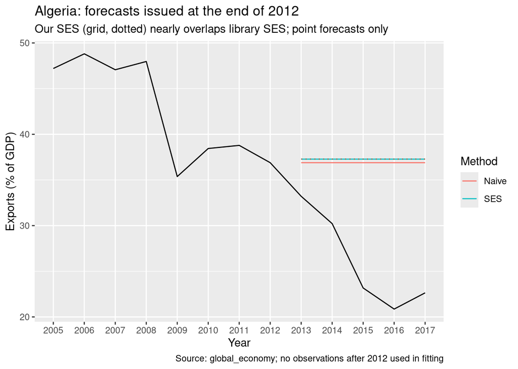

```r
test_forecasts |>
  autoplot(algerian_exports |> filter(Year >= 2005), level = NULL) +
  annotate("segment", x = 2013, xend = 2017,
           y = grid_forecast, yend = grid_forecast,
           linetype = "dotted", color = "#B45D3D") +
  scale_x_continuous(breaks = 2005:2017, minor_breaks = NULL) +
  labs(title = "Algeria: forecasts issued at the end of 2012",
       subtitle = "Our SES (grid, dotted) nearly overlaps library SES; point forecasts only",
       y = "Exports (% of GDP)", x = "Year", colour = "Method",
       caption = "Source: global_economy; no observations after 2012 used in fitting")
```

On this split, naive has the smallest test RMSE and MAE, although both SES fits have smaller training SSE on the matched years. The two SES forecasts are close. All three forecasts remain above the test observations as exports fall. This is evidence for this origin and these horizons, not a claim that naive always wins. The training ranking and the test ranking answer different questions; there is no requirement that they disagree. Session 14 on cross-validation repeats evaluation at several origins.

### Read what the training fit missed

**In-class check.** What do the time plot, ACF and histogram tell us that the test-set error table does not? Discuss your interpretation before opening the worked answer below.

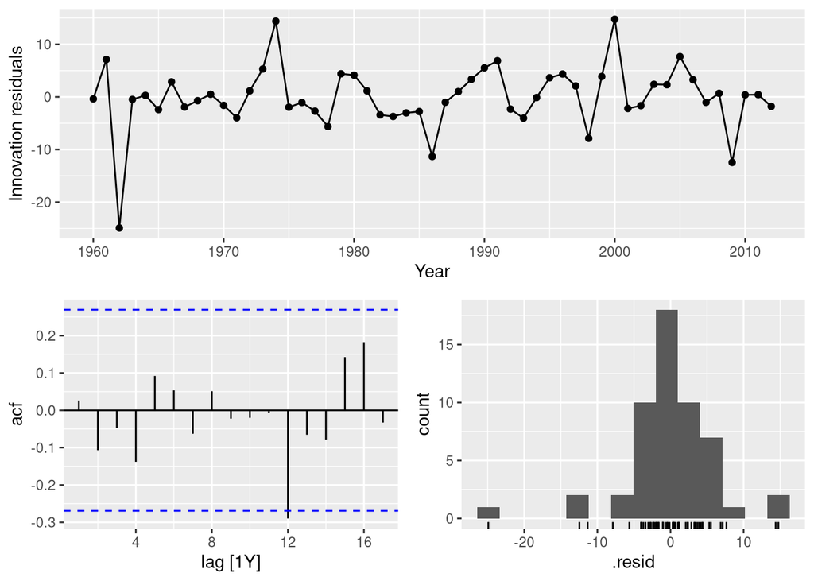

```r
training_fit |> select(SES) |> gg_tsresiduals()
```

**TipWorked interpretation: open after discussing in class**

Apply the four residual checks from Session 9 on residual diagnostics: autocorrelation, mean, spread and distribution shape.

- **Mean and unusual misses (time plot).** The residuals lie on both sides of zero, and their mean is about -0.05 percentage points, so there is little average bias in training. However, the model misses several large changes. In 1962 the residual is about -24.9 percentage points, so the preceding prediction was much too high. In 1974 and 2000, positive residuals of about 14.4 and 14.8 percentage points show that the model predicted too little. The plot locates these misses and shows their direction; a mean near zero does not make individual errors small.
- **Spread (time plot).** There is no clear funnel of steadily widening or narrowing residuals, but quiet stretches are interrupted by large misses. Isolated large residuals do not by themselves establish changing variance, so this plot calls for a cautious visual judgment about constant spread.
- **Autocorrelation (ACF).** Most bars are small and lie within the displayed bands, so there is little evidence of short-lag residual autocorrelation. However, the negative bar at lag 12 crosses the lower band slightly. An isolated crossing among many lags deserves inspection, but does not by itself establish a recurring pattern. We should not conclude that all residual dependence has disappeared. These are annual data, so lag 12 means twelve years.
- **Distribution shape (histogram).** Most residuals cluster around zero, but there are a few large errors on either side and a longer negative tail, including the 1962 miss. The distribution is not neatly symmetric, so a normal-error assumption needs more consideration than a quick glance at the central cluster. As in Session 9 on residual diagnostics and Session 12 on prediction intervals, this concern matters for intervals that rely on normal errors; normality is not required to calculate the point forecasts.

These plots describe the **training residuals**: when the model missed, whether the misses were related over time, and how their sizes were distributed. The test-set RMSE and MAE instead summarize the size of forecast errors on the five later observations. Here, the near-zero mean and small short-lag residual autocorrelations were encouraging signs for the training fit. Despite those signs, the model overpredicted the test years as exports fell. We therefore use residual diagnostics and test-set errors together when judging the model.

### What to keep

1. Fitting chooses parameters to reduce a criterion on past observations.
2. The criterion is a choice; SSE is one, and likelihood follows in Session 19.
3. A good training score does not establish forecasting skill.
4. Convergence reports a stopping rule being met, without certifying a global minimum, correct code or useful forecasts.
5. Check forecasts on held-out data and inspect what remains in the residuals.

Use 16_B for the required individual work.

# Appendix: optional practice and interface reference

This appendix is optional. Its additional programming details and repeated Argentina fit are not required in homework, group assignments or exams. The core ideas about fitting and predictive evidence remain in sections 1 to 5 above.

## Optional coding practice

Write the two functions yourself in a separate working file, then check against the supplied versions in sections 1 and 2. The templates below are incomplete and are not run as part of the workshop.

```r
ses_levels <- function(y, alpha, l_0) {
  levels <- numeric(length(y) + 1)
  levels[1] <- # TODO: initial level
  for (t in seq_along(y)) {
    levels[t + 1] <- # TODO: smoothing equation, using y[t] and levels[t]
  }
  levels
}
```

```r
SSE_func <- function(y, yhat) {
  residuals <- # TODO: observed minus predicted
  SSE <- # TODO: sum of squared residuals
  SSE
}
```

## A. Spreadsheet and R labels

The Session 15 SES workbook stores the initial state in D4, before its first observed row. The first observation is C5, its prediction E5 refers back to D4, and its revised level is D5. In `ses_levels()`, those two states are stored at positions 1 and 2. The initial state and each update produce $T+1$ stored levels for $T$ predictions.

## B. More about the supplied interface

`optim()` expects a function whose first argument is the candidate vector `par`; other arguments follow it. The same parameter order must be used in `my_ses_sse()`, starting guesses, bounds and returned estimates. The `counts` component records function and gradient evaluations, rather than elapsed time. `all.equal()` allows small floating-point differences when checking calculated vectors.

For software reference, see [R’s optim documentation](https://stat.ethz.ch/R-manual/R-devel/library/stats/html/optim.html). The mathematical fitting criterion is from [fpp3 section 8.1](https://otexts.com/fpp3/exponential-smoothing.html#optimisation).

## C. Practice extension: fit Argentina from scratch

Repeat the Algeria workflow on annual Argentina exports as a percentage of GDP. Inspect whether a level-only forecast is plausible, fit with your functions and `optim()`, then compare the training SSE and forecasts with `fable`. This repeats the workshop as optional coding practice; required homework `16_B` uses `fable` directly.

```r
arg_exports <- global_economy |>
  filter(Country == "Argentina") |>
  select(Year, Exports)
```